# Lesson1.1

BM XSTK

2026-01-29

## Phân bố xác suất

Mỗi phân phối mà R hỗ trợ đều có bốn hàm.

Tất cả chúng đều tuân theo cùng một nguyên tắc về cấu trúc tên, được tạo thành từ tên gốc của phân phối và tiền tố là một trong bốn chữ cái:

- p cho hàm phân phối tích lũy,
- d cho hàm mật độ hoặc hàm xác suất,
- q cho hàm lượng phân vị, nghịch đảo của hàm phân phối tích lũy,
- r là biến ngẫu nhiên có phân phối được chỉ định (bộ tạo giá trị ngẫu nhiên).

| Phân bố | Hàm mật độ | Hàm phân bố | Mô phỏng |
| --- | --- | --- | --- |
| Chuẩn | dnorm(x, mean,sd) | pnorm(x, mean,sd) | rnorm(n,mean,sd) |
| Nhị thức | dbinom(k,n,p) | pbinom(k,n,p) | rbinom(k,n,prob) |
| Poisson | dpois(k,lambda) | ppois(q,lambda) | rpois(n,lambda) |
| Uniform | dunif(x,min,max) | punif(q,min,max) | runif(n,min,max) |
| Nhị thức âm | dnbinom(x,k,p) | pnbinom(q,k,p) | rnbinom(n,n,prob) |
| Beta | dbeta(x,shape1,shape2) | pbeta(q,shape1,shape2) | rbeta(n,shape1,shape2) |
| Khi bình phương | dchisq(x,df) | pchisq(q,df) | rchisq(n,df) |
| Hình học | dgeom(x,p) | pgeom(q,p) | rgeom(n,prob) |
| Mũ | dexp(x,rate) | pexp(q,rate) | rexp(n,rate) |
| Student | dt(x,df) | pt(q,df) | rt(n,df) |
| Fisher | df(x,df1,df2) | pf(q,df1,df2) | rf(n,df1,df2) |

I. Mẫu ngẫu nhiên

1. Một trong những việc đầu tiên cần thực hiện là lấy mẫu ngẫu nhiên. R cung cấp hàm *sample()* để lấy mẫu từ các tập dữ liệu (đây là phương pháp lấy mẫu ngẫu nhiên đơn giản).

   ```r
   sample(6)
   ```

   ```
   ## [1] 3 5 6 4 2 1
   ```

   ```r
   sample(4:10)
   ```

   ```
   ## [1]  9  5 10  6  4  8  7
   ```

   ```r
   sample(1:40,5)
   ```

   ```
   ## [1] 33 38 26 10 39
   ```

   ```r
   #sample(6,50)
   ```

   ```r
   sample(6, 50, replace = TRUE)
   ```

   ```
   ##  [1] 1 3 6 6 2 6 6 1 4 1 2 4 6 6 4 4 2 6 2 6 2 3 5 5 1 2 2 5 4 5 1 2 6 5 3 1 1 4
   ## [39] 2 2 2 2 4 3 1 5 3 5 2 4
   ```

   Cuối cùng, chúng ta có thể thiết lập xác suất cho tất cả các kết quả có thể xảy ra, mà không nhất thiết phải giống nhau.

   Ví dụ, chúng ta có thể mô phỏng việc tung đồng xu không cân đối đồng chất với tần suất xuất hiện mặt ngửa cao hơn mặt sấp. Giả sử mặt ngửa xuất hiện nhiều gấp đôi mặt sấp. Khi đó, chúng ta đặt tham số $prob=c(2/3,1/3)$. Hãy xem kết quả trong danh sách sau (h nghĩa là “ngửa” và t nghĩa là “sấp”).

   ```r
   sample (c("h","t"),20, replace = TRUE ,prob=c(2/3,1/3))
   ```

   ```
   ##  [1] "h" "h" "h" "t" "t" "h" "t" "t" "h" "t" "t" "h" "h" "t" "h" "t" "h" "t" "h"
   ## [20] "t"
   ```

   ```r
   set.seed(3)
   sample(6)
   ```

   ```
   ## [1] 5 2 4 3 6 1
   ```

   II. Các phân bố rời rạc

Ví dụ: Tung đồng xu 3 lần, ta có không gian mẫu như sau:

$$S = \{HHH, HTH, THH, TTH, HHT, HTT, THT, TTT\}.$$

Bây giờ, gọi $X$ là số mặt ngửa (H). Khi đó các kết quả có thể có của $X$ là $S_X = \{0,1,2,3\}$.

Ta dễ dàng có bảng phân bố xác suất của $X$ như sau:

| $x \in S_X$ | 0 | 1 | 2 | 3 | Total |
| --- | --- | --- | --- | --- | --- |
| $f_X(x) = P(X=x)$ | 1/8 | 3/8 | 3/8 | 1/8 | 1 |

1. Các đặc trưng

```r
#Nhập dữ liệu
x <- c(0,1,2,3)
f <- c(1/8, 3/8, 3/8, 1/8)
```

Giá trị kỳ vọng: $E(X) = \sum\limits_i x_ip_i$

```r
mu <- sum(x*f)
mu
```

```
## [1] 1.5
```

```r
sigma2 <- sum((x-mu)^2 * f)
sigma2
```

```
## [1] 0.75
```

```r
sigma <- sqrt(sigma2)
sigma
```

```
## [1] 0.8660254
```

```r
F <- cumsum(f)
F
```

```
## [1] 0.125 0.500 0.875 1.000
```

```r
x <- c(4, 7, 9, 11, 12)
ecdf(x)
```

```
## Empirical CDF
## Call: ecdf(x)
##  x[1:5] =      4,      7,      9,     11,     12
```

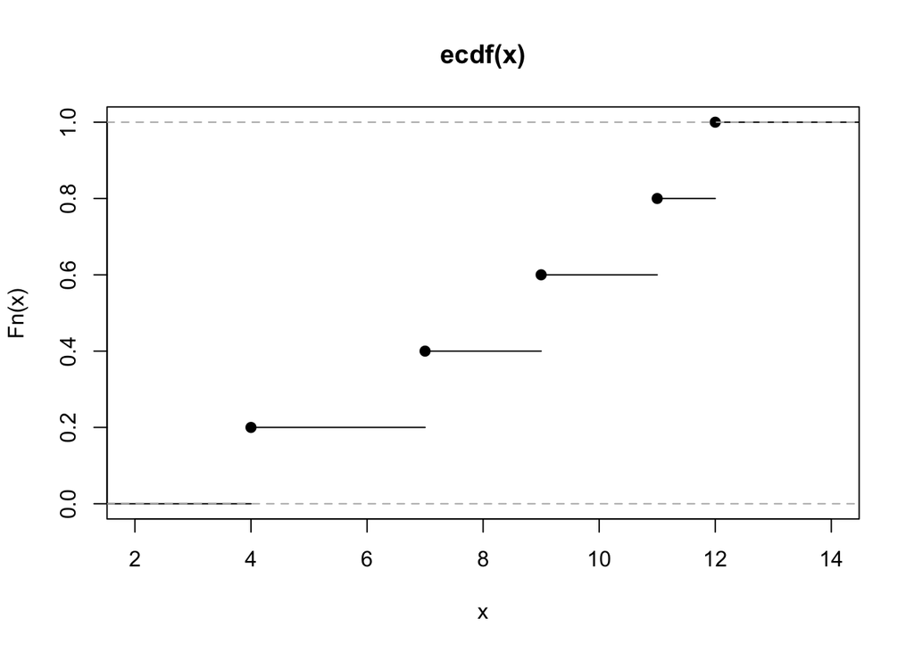

```r
plot(ecdf(x))
```

Đồ thị là của một hàm liên tục bên phải với các bước nhảy chính xác tại các vị trí được lưu trữ trong $x$. Không có giá trị lặp lại trong $x$ nên tất cả các bước nhảy đều bằng $1/5 = 0,2$.

Với hàm mật độ thì không có hàm có sẵn nên thường ta cần thiết lập hàm theo định nghĩa.

```r
epdf <- function(x) function(t){sum(x %in% t)/length(x)}
x <- c(0,0,1)
epdf(x)(0) # should be 2/3
```

```
## [1] 0.6666667
```

```r
#install.packages(c("sfsmisc", "distr", "startupmsg", "distrEx"))
library(distrEx)
X <- DiscreteDistribution(supp = 0:3, prob = c(1,3,3,1)/8)
E(X); var(X); sd(X)
```

```
## [1] 1.5
```

```
## [1] 0.75
```

```
## [1] 0.8660254
```

2. Phân bố nhị thức
   - *rbinom(n, p):* Trong đó n là số lượng quan sát cần sinh, p là xác suất thành công.  
     Hàm này dùng để sinh ra n biến ngẫu nhiên theo phân phối nhị thức với xác suất cho trước.
   - *pbinom(x, n, p):* Trong đó n là tổng số phép thử, p là xác suất thành công, x là giá trị cần tính xác suất.  
     Dùng để tính **xác suất tích lũy** của biến ngẫu nhiên tuân theo phân phối nhị thức đến một giá trị cho trước, tức là tính $P(X\leq x)$.
   - *dbinom(x, n, p):* Trong đó n là tổng số phép thử, p là xác suất thành công, x là giá trị cần tính xác suất.  
     Hàm này dùng để tính **xác suất tại đúng một giá trị cụ thể**, tức là $P(X=x)$.
   - *qbinom(prob, n, p):* Trong đó prob là xác suất cho trước, n là tổng số phép thử, p là xác suất thành công trong một phép thử. Hàm này dùng để tìm **phân vị**: nếu biết $P(X≤k)=prob$ thì hàm sẽ tìm giá trị $k$.

Ví dụ: Giả sử có 20 câu hỏi trắc nghiệm trong một bài kiểm tra. Mỗi câu có 5 đáp án, trong đó chỉ có 1 đáp án đúng. Hãy tìm xác suất để một học sinh trả lời **đúng không quá 6 câu**, nếu học sinh chọn đáp án hoàn toàn ngẫu nhiên cho mọi câu hỏi.

$$P(X\leq 6) = \sum\limits_{i=1}^6 P(X = x_i).$$

```r
dbinom (6 ,20 ,0.2) #P(X = 6)
```

```
## [1] 0.1090997
```

```r
dbinom (0 ,20 ,0.2)
```

```
## [1] 0.01152922
```

```r
dbinom (1 ,20 ,0.2)
```

```
## [1] 0.05764608
```

```r
dbinom (2 ,20 ,0.2)
```

```
## [1] 0.1369094
```

```r
dbinom (3 ,20 ,0.2)
```

```
## [1] 0.2053641
```

```r
dbinom (4 ,20 ,0.2)
```

```
## [1] 0.2181994
```

```r
dbinom (5 ,20 ,0.2)
```

```
## [1] 0.1745595
```

```r
dbinom (6 ,20 ,0.2)
```

```
## [1] 0.1090997
```

```r
pbinom (6 ,20 ,0.2)
```

```
## [1] 0.9133075
```

Bây giờ chúng ta hãy quay lại ví dụ trên. Sinh viên vượt qua kỳ thi thành công nếu trả lời đúng hơn 10 câu hỏi trong bài kiểm tra. Xác suất để sinh viên vượt qua kỳ thi nếu trả lời các câu hỏi một cách ngẫu nhiên là bao nhiêu?

$$P(X > 10).$$

```r
pbinom (10 ,20 ,0.2 , lower.tail=FALSE)
```

```
## [1] 0.0005634137
```

Ví dụ: Giả sử chúng ta phụ trách kiểm soát chất lượng cho một nhà máy. Chúng ta sản xuất $250$ sản phẩm mỗi ngày. Sản phẩm lỗi phải được làm lại. Chúng ta biết rằng tỷ lệ lỗi là $2\%$. Hãy mô phỏng xem chúng ta cần sửa chữa bao nhiêu sản phẩm mỗi ngày trong tuần này.

```r
rbinom (7 ,250 ,0.02)
```

```
## [1] 3 4 5 6 5 5 5
```

```r
qbinom (0.2 ,30 ,0.8) #Tìm k để P(X \leq k)=0.2
```

```
## [1] 22
```

```r
qbinom(seq (0.1 ,1 ,0.1) ,30 ,0.8)
```

```
##  [1] 21 22 23 24 24 25 25 26 27 30
```

3. Phân bố Poisson
   - *dpois(x, lambda):* Dùng để tính **giá trị hàm phân bố xác suất** $P(X=x)$ của **phân phối Poisson** với tham số $\lambda$, trong đó tham số $\lambda$ được truyền vào dưới tên $l$.
   - *ppois(x, l):* Dùng để tính **hàm phân phối tích lũy** của một biến ngẫu nhiên tuân theo phân phối Poisson.  
     Hàm trả về xác suất để biến ngẫu nhiên nhận giá trị **nhỏ hơn hoặc bằng** $x$, tức là $P(X≤x)$.

     Tham số $l$ là tham số của phân phối.  
     Nếu thêm đối số `lower.tail = FALSE` thì ta xét **đuôi phải** của phân phối, khi đó ta thu được xác suất $P(X>x)$.
   - *rpois(k, l):* Dùng để **sinh các số ngẫu nhiên** theo phân phối Poisson.  
     Trong đó $k$ là số lượng giá trị ngẫu nhiên cần sinh, còn $l$là tham số của phân phối.
   - *qpois(q,l):* Dùng để **tìm phân vị (quantile)** của phân phối Poisson.  
     Ở đây $q$ là một vector các mức phân vị cần tìm, còn $l$ là tham số của phân phối.

```r
x<-seq (0:6)
dpois(x ,1)
```

```
## [1] 3.678794e-01 1.839397e-01 6.131324e-02 1.532831e-02 3.065662e-03
## [6] 5.109437e-04 7.299195e-05
```

Ví dụ: Một nhân viên bán bảo hiểm nhân thọ bán trung bình 3 hợp đồng bảo hiểm nhân thọ mỗi tuần. Hãy tính xác suất để trong một tuần nhất định anh ta bán được một số hợp đồng.

Giải pháp: “Một số hợp đồng” có nghĩa là “1 hoặc nhiều hợp đồng” và do đó chúng ta phải tính xác suất $P(X> 0) = 1 - P(X \leq 0)$. Chúng ta sẽ áp dụng hàm **ppois()** với đối số bổ sung **lower.tail** được đặt thành **FALSE**. Tham số của phân phối là $l = 3$ số hợp đồng được bán trong một tuần. Vì vậy, ta thu được

```r
ppois (0,3, lower.tail=FALSE)
```

```
## [1] 0.9502129
```

```r
1-dpois (0 ,3)
```

```
## [1] 0.9502129
```

Ví dụ: Một công ty sản xuất $300$ động cơ điện mỗi ngày. Xác suất một động cơ điện bị lỗi là $0,01$. Hãy tính số lượng động cơ bị lỗi được sản xuất mỗi ngày trong một tuần làm việc.

Giải pháp: Số lượng động cơ bị lỗi trung bình trong sản lượng $300$ động cơ mỗi ngày là $\lambda = 0,01 \times 300 = 3$. Để tính số lượng động cơ bị lỗi hàng ngày, ta sử dụng hàm **rpois()** với các tham số $k=5$ ngày làm việc và $l=3$. Vì vậy, ta được

```r
rpois (5 ,3)
```

```
## [1] 3 5 5 1 4
```

Ví dụ: Xét một hệ thống máy tính với luồng công việc đến theo phân phối Poisson, trung bình là $2$ công việc mỗi phút. Số lượng công việc tối đa có thể đến trong một phút với độ chắc chắn $90\%$ là bao nhiêu?

Giải pháp: Để tìm số lượng công việc đến tối đa với độ chắc chắn ít nhất $90\%$, ta cần tìm phân vị $90\%$. Ta có thể áp dụng hàm **qpois()** với các tham số $q=0,9$ và $l=2$ (số lượng công việc đến trung bình mỗi phút). Vì vậy, ta có:

```r
qpois (0.9 ,2)
```

```
## [1] 4
```

III. Phân bố liên tục

Trong trường hợp biến ngẫu nhiên có các phân bố là những phân bố có sẵn trong R thì ta sử dụng các hàm tương tự như ở rời rạc. Còn trường hợp không có thì ta cần xây dựng các hàm mật độ và xác suất để tính toán.

```r
f <- function(x) 3*x^2
integrate(f, lower = 0.14, upper = 0.71)
```

```
## 0.355167 with absolute error < 3.9e-15
```

Tự kiểm tra lại với kết quả tính tay.

```r
g <- function(x) 3/x^3
integrate(g, lower = 1, upper = Inf)
```

```
## 1.5 with absolute error < 1.7e-14
```

Bây giờ, ta sử dụng “distr” package có sẵn để tính toán như sau:

```r
f <- function(x) 3*x^2
X <- AbscontDistribution(d = f, low1 = 0, up1 = 1)
p(X)(0.71)- p(X)(0.14)
```

```
## [1] 0.355167
```

```r
E(X); var(X)
```

```
## [1] 0.7496337
```

```
## [1] 0.03768305
```

**Phần liên quan đến các hàm có sẵn của các phân bố liên tục được coi như bài tập thực hành.**

**IV. Các đồ thị và gói lệnh ggplot2**

Để có cái nhìn trực quan về dữ liệu ta cần sử dụng và đánh giá cả trên các biểu đồ. Từ bây giờ ta sẽ sử dụng gói lệnh ggplot2 để thực hiện việc vẽ đồ thị.

```r
#install.packages(c("ggplot2","tidyverse"))
library(ggplot2) #giúp vẽ biểu đồ
library(tidyverse) #giúp biến đổi số liệu tốt hơn
```

Cấu trúc cơ bản của ggplot2

Một câu lệnh đầy đủ để vẽ được một biểu đồ cơ bản trong ggplot2 là

`ggplot(data, mapping) + geom_biểu đồ()`

Trong đó:

- data: data frame chứa số liệu cần vẽ biểu đồ.
- mapping: đối tượng chứa các thông số về trục x, y, nhóm, màu sắc, kích thước,… được tạo ra từ aes().
- ggplot(data, mapping): nền cơ sở, từ đây sẽ dựng các biểu đồ khác lên.
- geom_biểuđồ(): loại biểu đồ cần vẽ. Ví dụ muốn vẽ biểu đồ tán xạ (biểu đồ điểm), ta dùng geom_point().

Lưu ý: Ta có thể vẽ nhiều biểu đồ khác nhau cùng lúc trên cùng một nền cơ sở:

`ggplot(data, mapping) + geom_point + geom_bar +...`

Ví dụ:

```r
head(mtcars)
```

```
##                    mpg cyl disp  hp drat    wt  qsec vs am gear carb
## Mazda RX4         21.0   6  160 110 3.90 2.620 16.46  0  1    4    4
## Mazda RX4 Wag     21.0   6  160 110 3.90 2.875 17.02  0  1    4    4
## Datsun 710        22.8   4  108  93 3.85 2.320 18.61  1  1    4    1
## Hornet 4 Drive    21.4   6  258 110 3.08 3.215 19.44  1  0    3    1
## Hornet Sportabout 18.7   8  360 175 3.15 3.440 17.02  0  0    3    2
## Valiant           18.1   6  225 105 2.76 3.460 20.22  1  0    3    1
```

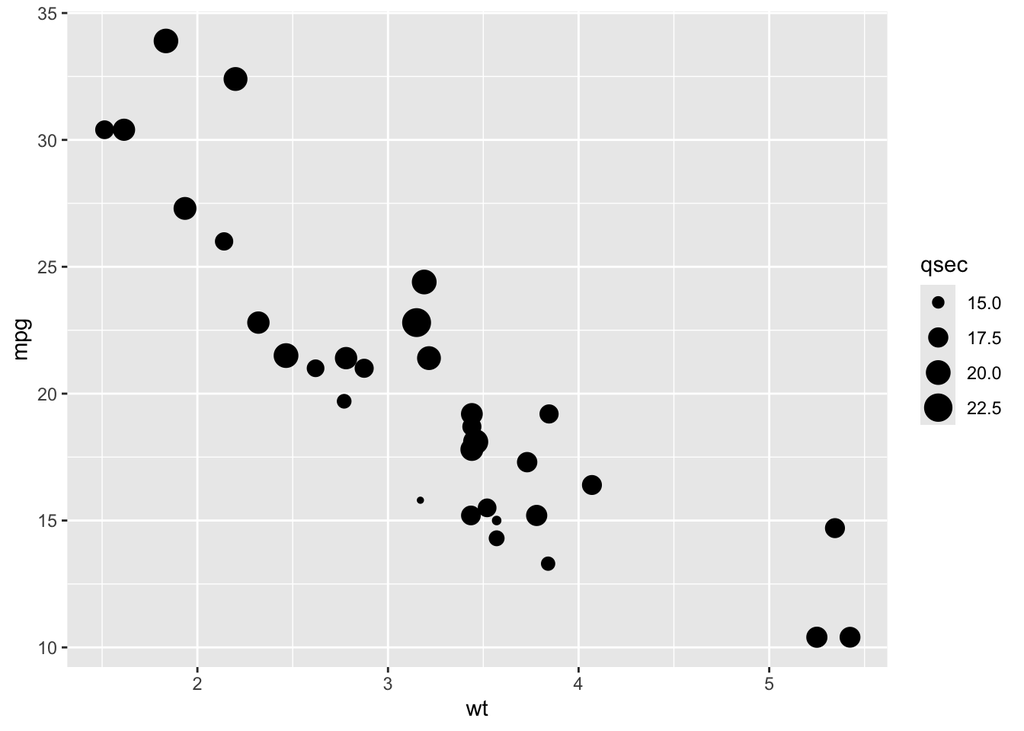

```r
ggplot(data = mtcars, mapping = aes(x = wt, y = mpg)) +
  geom_point(aes(size = qsec))
```

Nếu số liệu không được khai báo trong mỗi hàm vẽ biểu đồ (geom_point(), geom_bar(),…) thì hàm sẽ lấy số liệu từ nền cơ sở ggplot().

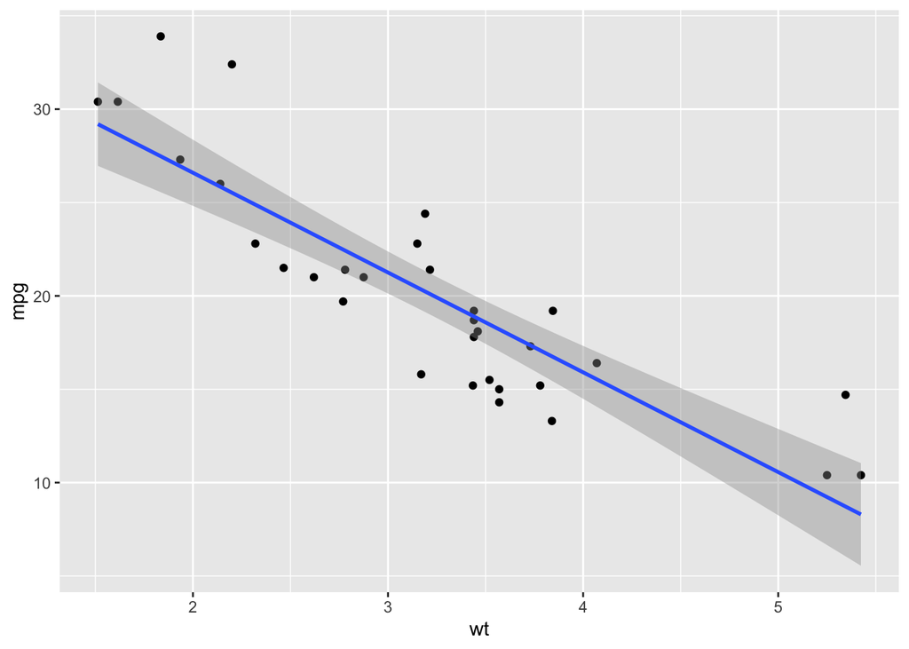

```r
ggplot(data = mtcars, mapping = aes(x = wt, y = mpg)) +
  geom_point() +
  geom_smooth(method="lm")
```

Lúc này `geom_point()` và `geom_smooth()` sẽ lấy số liệu của x, y trong `ggplot()`. Ta thấy có cả 2 loại biểu đồ trên cùng 1 nền cơ sở (cùng hệ trục tọa độ).

1. Biểu đồ phân tán

   Biểu đồ phân tán (scatter plot):
   - Sử dụng các dấu chấm để thể hiện giá trị (điểm giao nhau) của hai biến số khác nhau.
   - Dùng để quan sát mối tương quan giữa 2 biến định lượng.
   - Trục hoành (trục X) mô tả biến độc lập. Trục tung (Y) mô tả biến phụ thuộc.

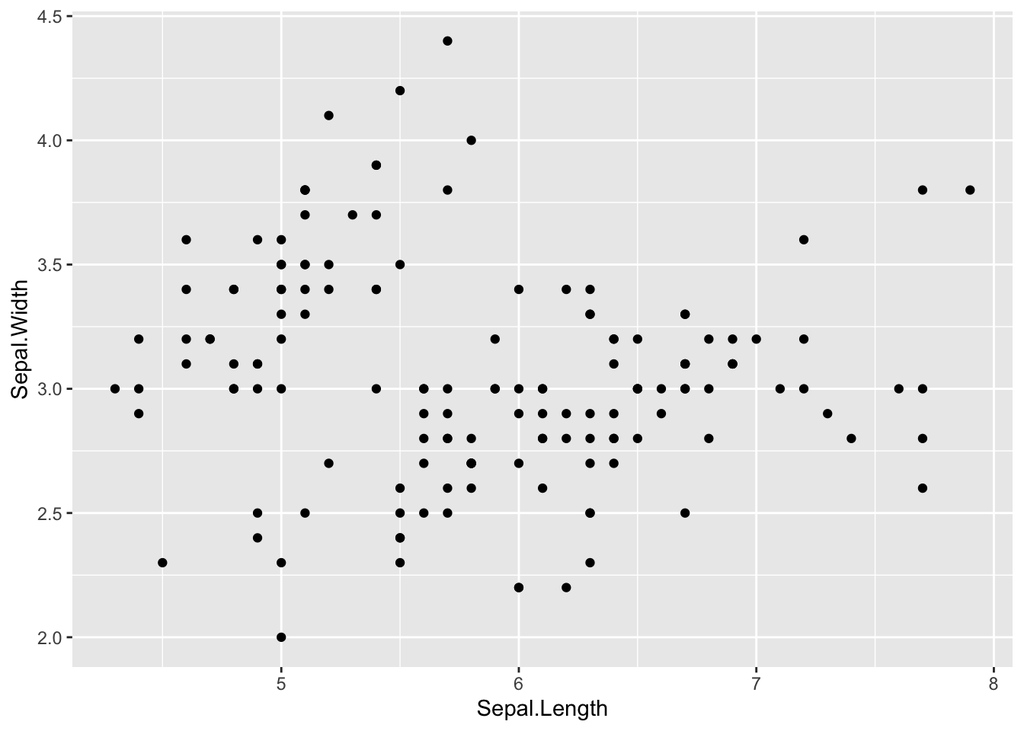

```r
ggplot(data=iris, mapping = aes(x = Sepal.Length, y = Sepal.Width)) +
  geom_point()
```

Lưu ý: Không phải tất cả mối liên quan thể hiện trên biểu đồ phân tán đều là mối quan hệ nhân quả. Có thể do ảnh hưởng của các biến số khác khiến ta lầm tưởng sự tương quan khi khảo sát 2 biến số đơn độc.

Ví dụ: Sử dụng bộ dữ liệu “mpg”

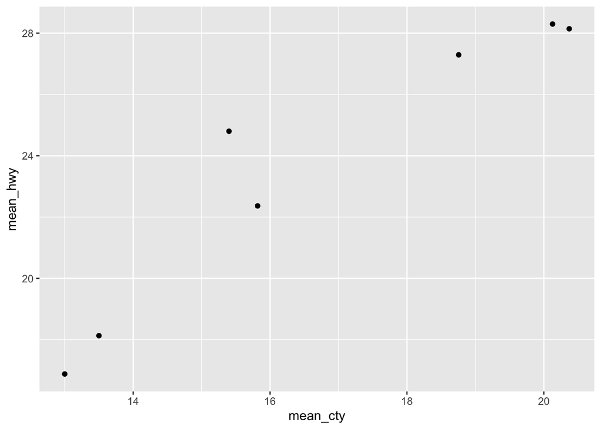

```r
mpg %>%
  dplyr::group_by(class) %>%
  summarise(mean_cty = mean(cty), mean_hwy = mean(hwy)) %>%
  ggplot(aes(x = mean_cty, y = mean_hwy)) +
  geom_point()
```

Mỗ điểm trên biểu đồ tương ứng với 1 loại xe (class). Như ta thấy mỗi loại xe sẽ có chỉ số **cty** và **hwy** trung bình khác nhau.

Để thể hiện rõ hơn từng loại xe, ta thay thế `geom_point()` bằng `geom_label().`

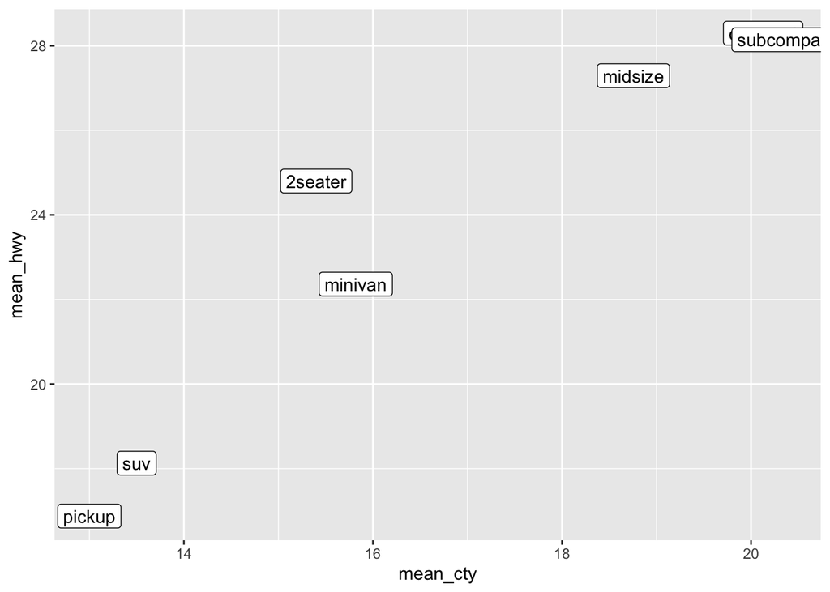

```r
mpg %>%
  dplyr::group_by(class) %>%
  summarise(mean_cty = mean(cty), mean_hwy = mean(hwy)) %>%
  ggplot(aes(x = mean_cty, y = mean_hwy)) +
  geom_label(aes(label=class))
```

Biểu đồ này thể hiện chi tiết hơn biểu đồ 1, tuy nhiên có 2 giá trị bị chồng lên nhau, khiến ta không thể đọc được.

Ta có thể thay thế bằng `ggrepel::geom_label_repel()` để khắc phục.

```r
#install.packages("ggrepel")
```

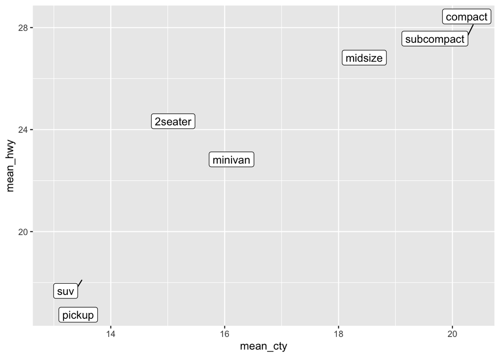

```r
library(ggrepel)
mpg %>%
  dplyr::group_by(class) %>%
  summarise(mean_cty = mean(cty), mean_hwy = mean(hwy)) %>%
  ggplot(aes(x = mean_cty, y = mean_hwy)) +
  geom_label_repel(aes(label=class))
```

2. Biểu đồ histogram

   Biểu đồ histogram dùng để mô tả phân bố của một biến liên tục (continuous).

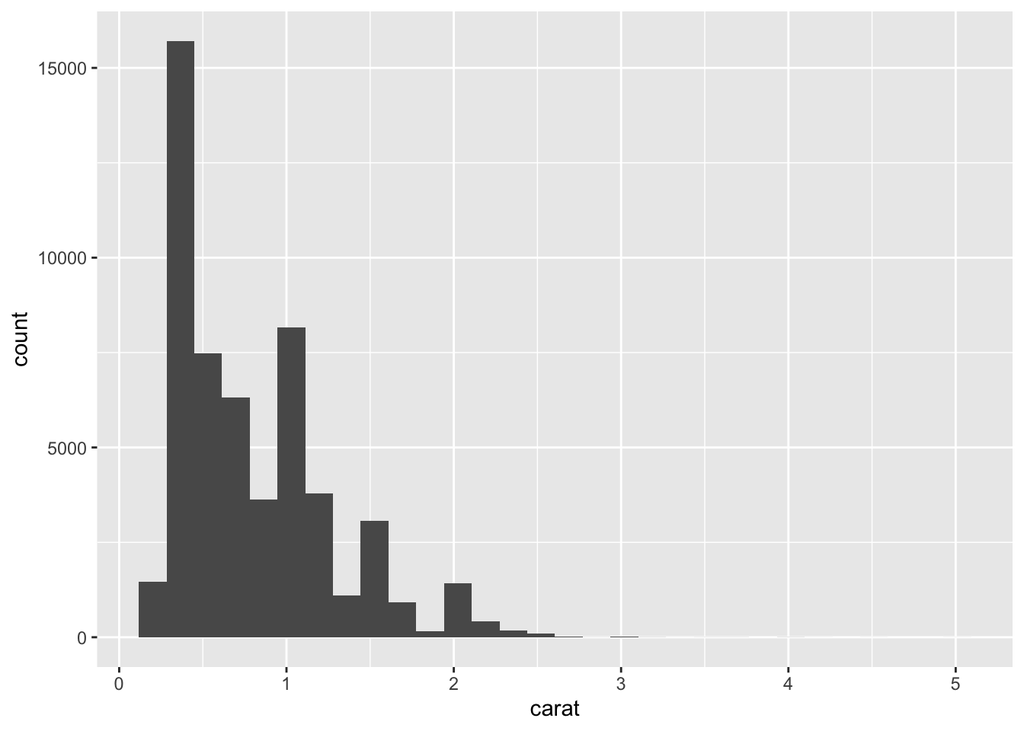

```r
ggplot(data = diamonds) +
  geom_histogram(aes(x = carat))
```

Ta chỉ cần cung cấp giá trị cho trục x, trục y sẽ được tự động tạo ra bằng các đếm số quan sát nằm trên từng khoảng của x (khoảng này là độ rộng của mỗi cột, còn gọi là *binwidth*).

Khi thay đổi *binwidth*, tức là ta đang thay đổi số lượng quan sát của mỗi khoảng giá trị trên trục x. Khi đó hình dạng của histogram cũng sẽ thay đổi theo.

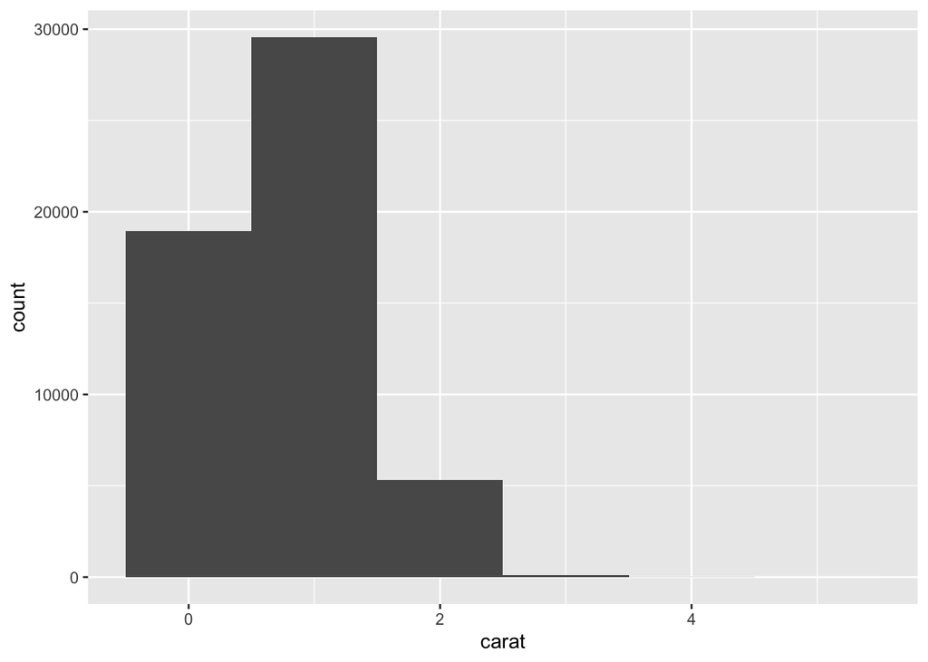

```r
ggplot(data = diamonds) +
  geom_histogram(mapping = aes(x = carat), binwidth = 1)
```

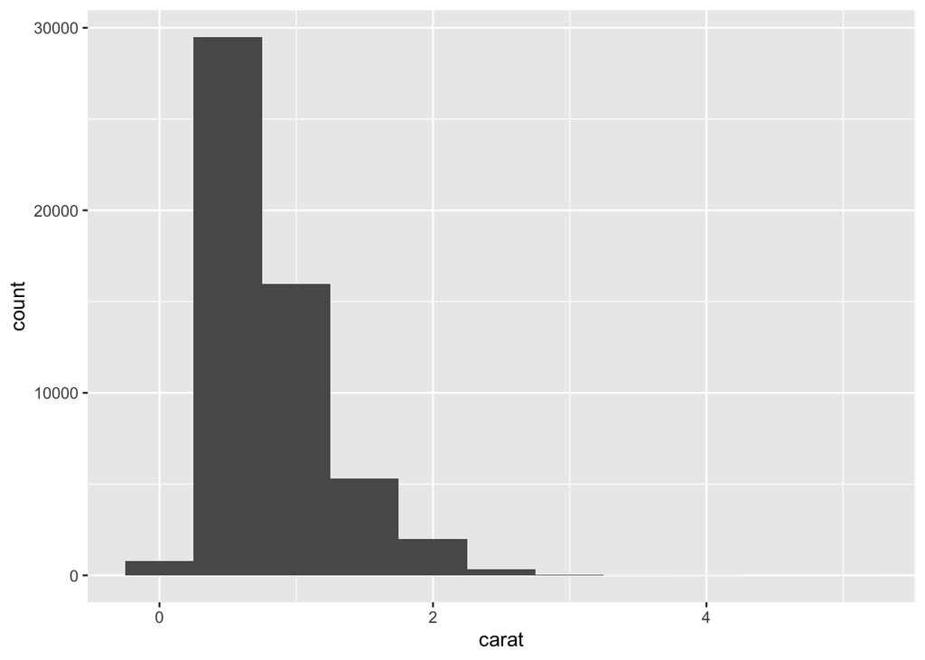

```r
ggplot(data = diamonds) +
  geom_histogram(mapping = aes(x = carat), binwidth = 0.5)
```

Ngược với binwidth, *bins* là số khoảng chia trên trục x (số cột của histogram) Ví dụ khi ta muốn vẽ histogram chỉ có 4 cột.

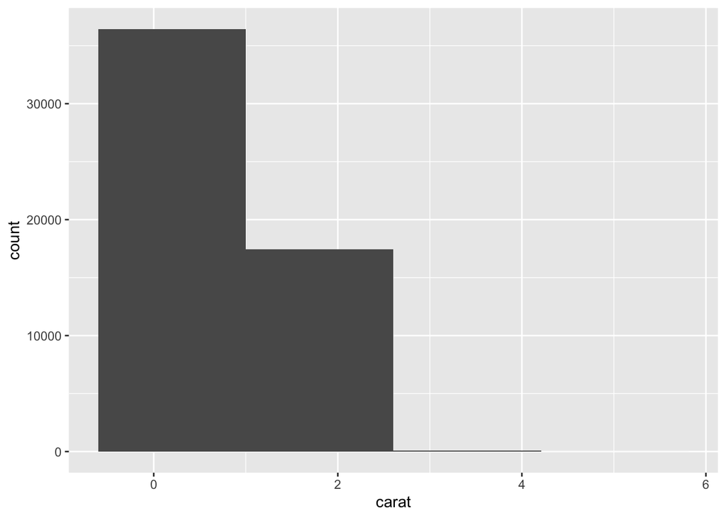

```r
ggplot(data = diamonds) +
  geom_histogram(mapping = aes(x = carat), bins = 4)
```

Tương tự biểu đồ cột, histogram có thể phân nhóm ra bằng tham số **fill.**

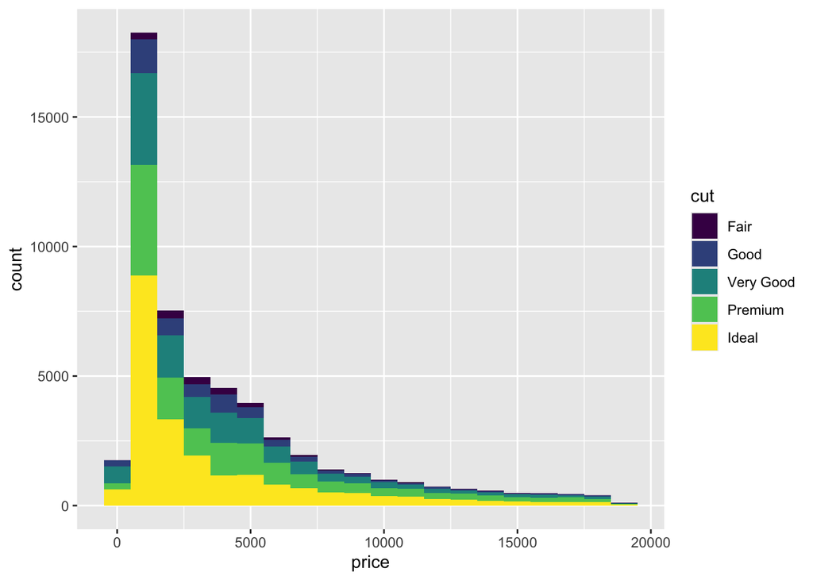

```r
ggplot(data = diamonds) +
  geom_histogram(mapping = aes(x = price, fill = cut), binwidth = 1000)
```

Phân nhóm theo loại nhát cắt của các viên kim cương.